# Assignment 2

Edward Kim

9/20/2020

```r
download.file("https://raw.githubusercontent.com/USCbiostats/data-science-data/master/01_chs/chs_individual.csv", destfile= "individual.csv")
download.file("https://raw.githubusercontent.com/USCbiostats/data-science-data/master/01_chs/chs_regional.csv", destfile = "regional.csv")

individual <- data.table::fread("individual.csv")
regional <- data.table::fread("regional.csv")
```

# Data Wrangling

## 1. Merge the two data sets

```r
merge <-merge(
  x = individual,
  y = regional,
  by.x = "townname",
  by.y = "townname",
  all.x = TRUE,
  all.y = TRUE)

head(merge)
```

```
##    townname sid male race hispanic    agepft height weight      bmi asthma
## 1:   Alpine 835    0    W        0 10.099932    143     69 15.33749      0
## 2:   Alpine 838    0    O        1  9.486653    133     62 15.93183      0
## 3:   Alpine 839    0    M        1 10.053388    142     86 19.38649      0
## 4:   Alpine 840    0    W        0  9.965777    146     78 16.63283      0
## 5:   Alpine 841    1    W        1 10.548939    150     78 15.75758      0
## 6:   Alpine 842    1    M        1  9.489391    139     65 15.29189      0
##    active_asthma father_asthma mother_asthma wheeze hayfever allergy
## 1:             0             0             0      0        0       1
## 2:             0             0             0      0        0       0
## 3:             0             0             1      1        1       1
## 4:             0             0             0      0        0       0
## 5:             0             0             0      0        0       0
## 6:             0             0             0      1        0       0
##    educ_parent smoke pets gasstove      fev      fvc     mmef pm25_mass
```

[output cut: 27 more lines]

```r
merge %>% nrow()
```

```
## [1] 1200
```

The two dataset for the individual and regional levels were merged using the location (townname). There is a total of 1200 rows, which confirms that there was no duplicates in the data. There is 49 total variables, which is consistent with the variables present in both datasets.

## 2. Create new categorical variable

```r
merge <- merge %>%
  mutate("obesity_level" = case_when( bmi<14 ~ "Underweight",
                                      bmi>=14 & bmi <22 ~"Normal",
                                      bmi>=22 & bmi<24 ~"Overweight",
                                      bmi>=24 ~ "Obese")
  )

merge[,obesity_level:= fifelse(is.na(obesity_level),"Normal",obesity_level)]
summary(merge$bmi)
```

```
##    Min. 1st Qu.  Median    Mean 3rd Qu.    Max.    NA's
##   11.30   15.78   17.48   18.50   20.35   41.27      89
```

```r
merge %>% count(obesity_level)
```

```
##    obesity_level   n
## 1:        Normal 975
## 2:         Obese 103
## 3:    Overweight  87
## 4:   Underweight  35
```

Because the mean BMI of 18.5 and the median BMI of 17.48 are both in the Healthy category, a majority of the observations would be Healthy.

## 3. Create Categorical Variable “Smoke_gas_exposure”

```r
merge %>% group_by(smoke,gasstove) %>% count()
```

```
## # A tibble: 9 x 3
## # Groups:   smoke, gasstove [9]
##   smoke gasstove     n
##   <int>    <int> <int>
## 1     0        0   214
## 2     0        1   739
## 3     0       NA    17
## 4     1        0    36
## 5     1        1   151
## 6     1       NA     3
## 7    NA        0     5
## 8    NA        1    22
## 9    NA       NA    13
```

```r
merge <- merge %>% mutate(smoke_gas_exposure = case_when(smoke==0 & gasstove ==0 ~ "No Exposure",
                                                         smoke==0 & gasstove==1 ~ "Gas Exposure",
                                                         smoke==1 & gasstove ==0~ "Smoke Exposure",
                                                         smoke==1 & gasstove ==1 ~ "Smoke and Gas Exposure",
                                                         )
                          )
merge[,smoke_gas_exposure := fifelse(is.na(smoke_gas_exposure),"Gas Exposure",smoke_gas_exposure)]
merge %>% count(smoke_gas_exposure)
```

```
##        smoke_gas_exposure   n
## 1:           Gas Exposure 799
## 2:            No Exposure 214
## 3: Smoke and Gas Exposure 151
## 4:         Smoke Exposure  36
```

Four different categories were created indicating whether the participant was exposed to second-hand smoke, a gas stove, or both.

## 4. Create four summary tables

```r
merge %>% group_by(townname) %>%
  summarise(
    fev_avg = mean(fev, na.rm=TRUE),
    asthma.indication = mean(asthma, na.rm = TRUE)
    )
```

```
## # A tibble: 12 x 3
##    townname      fev_avg asthma.indication
##    <chr>           <dbl>             <dbl>
##  1 Alpine          2089.             0.113
##  2 Atascadero      2079.             0.255
##  3 Lake Elsinore   2040.             0.126
##  4 Lake Gregory    2092.             0.152
##  5 Lancaster       2003.             0.165
##  6 Lompoc          2038.             0.113
##  7 Long Beach      1984.             0.135
##  8 Mira Loma       1985.             0.158
##  9 Riverside       1986.             0.11
## 10 San Dimas       2028.             0.172
## 11 Santa Maria     2023.             0.134
## 12 Upland          2027.             0.121
```

```r
merge <- merge %>% mutate(male.f = case_when( male == 0 ~ "Female",
                                              male == 1 ~ "Male"))

merge %>% group_by(male.f) %>%
  summarise(
    fev_avg = mean(fev, na.rm=TRUE),
    asthma.indication = mean(asthma, na.rm = TRUE)
    )
```

```
## # A tibble: 2 x 3
##   male.f fev_avg asthma.indication
##   <chr>    <dbl>             <dbl>
## 1 Female   1959.             0.121
## 2 Male     2104.             0.173
```

```r
merge %>% group_by(obesity_level) %>%
  summarise(
    fev_avg = mean(fev, na.rm=TRUE),
    asthma.indication = mean(asthma, na.rm = TRUE)
    )
```

```
## # A tibble: 4 x 3
##   obesity_level fev_avg asthma.indication
##   <chr>           <dbl>             <dbl>
## 1 Normal          1998.            0.140
## 2 Obese           2269.            0.21
## 3 Overweight      2224.            0.165
## 4 Underweight     1687.            0.0857
```

```r
merge %>% group_by(smoke_gas_exposure) %>%
  summarise(
    fev_avg = mean(fev, na.rm=TRUE),
    asthma.indication = mean(asthma, na.rm = TRUE)
    )
```

```
## # A tibble: 4 x 3
##   smoke_gas_exposure     fev_avg asthma.indication
##   <chr>                    <dbl>             <dbl>
## 1 Gas Exposure             2024.             0.148
## 2 No Exposure              2060.             0.148
## 3 Smoke and Gas Exposure   2020.             0.130
## 4 Smoke Exposure           2064.             0.171
```

# Looking at the Data

Q1: What is the association between BMI and FEV?

Q2: What is the association between smoke and gas exposure and FEV?

Q3: What is the assoication between PM2.5 exposure and FEV?

### Initial EDA Checklist:

```r
dim(merge)
```

```
## [1] 1200   52
```

```r
head(merge)
```

```
##    townname sid male race hispanic    agepft height weight      bmi asthma
## 1:   Alpine 835    0    W        0 10.099932    143     69 15.33749      0
## 2:   Alpine 838    0    O        1  9.486653    133     62 15.93183      0
## 3:   Alpine 839    0    M        1 10.053388    142     86 19.38649      0
## 4:   Alpine 840    0    W        0  9.965777    146     78 16.63283      0
## 5:   Alpine 841    1    W        1 10.548939    150     78 15.75758      0
## 6:   Alpine 842    1    M        1  9.489391    139     65 15.29189      0
##    active_asthma father_asthma mother_asthma wheeze hayfever allergy
## 1:             0             0             0      0        0       1
## 2:             0             0             0      0        0       0
## 3:             0             0             1      1        1       1
## 4:             0             0             0      0        0       0
## 5:             0             0             0      0        0       0
## 6:             0             0             0      1        0       0
##    educ_parent smoke pets gasstove      fev      fvc     mmef pm25_mass
```

[output cut: 34 more lines]

```r
tail(merge)
```

```
##    townname  sid male race hispanic    agepft height weight      bmi asthma
## 1:   Upland 1866    0    O        1  9.806982    139     60 14.11559      0
## 2:   Upland 1867    0    M        1  9.618070    140     71 16.46568      0
## 3:   Upland 2031    1    W        0  9.798768    135     83 20.70084      0
## 4:   Upland 2032    1    W        0  9.549624    137     59 14.28855      0
## 5:   Upland 2033    0    M        0 10.121834    130     67 18.02044      0
## 6:   Upland 2053    0    W        0        NA     NA     NA       NA      0
##    active_asthma father_asthma mother_asthma wheeze hayfever allergy
## 1:             0            NA             0      0       NA      NA
## 2:             0             1             0      0        0       0
## 3:             0             0             0      1        0       1
## 4:             0             0             1      1        1       1
## 5:             1             0             0      1        1       0
## 6:             0             0             0      0        0       0
##    educ_parent smoke pets gasstove      fev      fvc     mmef pm25_mass
```

[output cut: 27 more lines]

```r
summary(merge)
```

```
##    townname              sid              male            race
##  Length:1200        Min.   :   1.0   Min.   :0.0000   Length:1200
##  Class :character   1st Qu.: 528.8   1st Qu.:0.0000   Class :character
##  Mode  :character   Median :1041.5   Median :0.0000   Mode  :character
##                     Mean   :1037.5   Mean   :0.4917
##                     3rd Qu.:1554.2   3rd Qu.:1.0000
##                     Max.   :2053.0   Max.   :1.0000
##
##     hispanic          agepft           height        weight
##  Min.   :0.0000   Min.   : 8.961   Min.   :114   Min.   : 42.00
##  1st Qu.:0.0000   1st Qu.: 9.610   1st Qu.:135   1st Qu.: 65.00
##  Median :0.0000   Median : 9.906   Median :139   Median : 74.00
##  Mean   :0.4342   Mean   : 9.924   Mean   :139   Mean   : 79.33
##  3rd Qu.:1.0000   3rd Qu.:10.177   3rd Qu.:143   3rd Qu.: 89.00
##  Max.   :1.0000   Max.   :12.731   Max.   :165   Max.   :207.00
##                   NA's   :89       NA's   :89    NA's   :89
##       bmi            asthma       active_asthma  father_asthma
##  Min.   :11.30   Min.   :0.0000   Min.   :0.00   Min.   :0.00000
##  1st Qu.:15.78   1st Qu.:0.0000   1st Qu.:0.00   1st Qu.:0.00000
##  Median :17.48   Median :0.0000   Median :0.00   Median :0.00000
##  Mean   :18.50   Mean   :0.1463   Mean   :0.19   Mean   :0.08318
##  3rd Qu.:20.35   3rd Qu.:0.0000   3rd Qu.:0.00   3rd Qu.:0.00000
##  Max.   :41.27   Max.   :1.0000   Max.   :1.00   Max.   :1.00000
##  NA's   :89      NA's   :31                      NA's   :106
##  mother_asthma        wheeze          hayfever         allergy
##  Min.   :0.0000   Min.   :0.0000   Min.   :0.0000   Min.   :0.0000
##  1st Qu.:0.0000   1st Qu.:0.0000   1st Qu.:0.0000   1st Qu.:0.0000
##  Median :0.0000   Median :0.0000   Median :0.0000   Median :0.0000
##  Mean   :0.1023   Mean   :0.3313   Mean   :0.1747   Mean   :0.2929
##  3rd Qu.:0.0000   3rd Qu.:1.0000   3rd Qu.:0.0000   3rd Qu.:1.0000
##  Max.   :1.0000   Max.   :1.0000   Max.   :1.0000   Max.   :1.0000
##  NA's   :56       NA's   :71       NA's   :118      NA's   :63
##   educ_parent        smoke             pets           gasstove
##  Min.   :1.000   Min.   :0.0000   Min.   :0.0000   Min.   :0.0000
##  1st Qu.:2.000   1st Qu.:0.0000   1st Qu.:1.0000   1st Qu.:1.0000
##  Median :3.000   Median :0.0000   Median :1.0000   Median :1.0000
##  Mean   :2.797   Mean   :0.1638   Mean   :0.7667   Mean   :0.7815
##  3rd Qu.:3.000   3rd Qu.:0.0000   3rd Qu.:1.0000   3rd Qu.:1.0000
##  Max.   :5.000   Max.   :1.0000   Max.   :1.0000   Max.   :1.0000
##  NA's   :64      NA's   :40                        NA's   :33
```

[output cut: 49 more lines]

```
##  Min.   :0.760   Min.   :1.090   Min.   : 1.520   Min.   :-120.7
##  1st Qu.:1.835   1st Qu.:2.978   1st Qu.: 4.930   1st Qu.:-118.8
##  Median :2.825   Median :4.135   Median : 6.370   Median :-117.7
##  Mean   :2.788   Mean   :4.342   Mean   : 6.708   Mean   :-118.3
##  3rd Qu.:3.817   3rd Qu.:5.982   3rd Qu.: 9.395   3rd Qu.:-117.4
##  Max.   :4.620   Max.   :7.400   Max.   :11.430   Max.   :-116.8
##
##       lat        obesity_level      smoke_gas_exposure    male.f
##  Min.   :32.84   Length:1200        Length:1200        Length:1200
##  1st Qu.:33.93   Class :character   Class :character   Class :character
##  Median :34.10   Mode  :character   Mode  :character   Mode  :character
##  Mean   :34.20
##  3rd Qu.:34.65
##  Max.   :35.49
##
```

Overall, there does not seem to be any issues with the data. We will check the variables that we are analyzing more closely (BMI,FEV,PM2.5, and smoke and gas exposure)

```r
summary(merge$fev)
```

```
##    Min. 1st Qu.  Median    Mean 3rd Qu.    Max.    NA's
##   984.8  1809.0  2022.7  2031.3  2249.7  3323.7      95
```

```r
summary(merge$pm25_mass)
```

```
##    Min. 1st Qu.  Median    Mean 3rd Qu.    Max.
##   5.960   7.615  10.545  14.362  20.988  29.970
```

```r
summary(merge$bmi)
```

```
##    Min. 1st Qu.  Median    Mean 3rd Qu.    Max.    NA's
##   11.30   15.78   17.48   18.50   20.35   41.27      89
```

```r
table(merge$smoke_gas_exposure)
```

```
##
##           Gas Exposure            No Exposure Smoke and Gas Exposure
##                    799                    214                    151
##         Smoke Exposure
##                     36
```

```r
table(merge$obesity_level)
```

```
##
##      Normal       Obese  Overweight Underweight
##         975         103          87          35
```

The key variables that we are analyzing all seem to have plausible values, and there does not seem to be an error in them. The NA’s in the FEV category were all discarded when calculations were run.

## 1. Facet Plot, BMI vs FEV by “Townname”

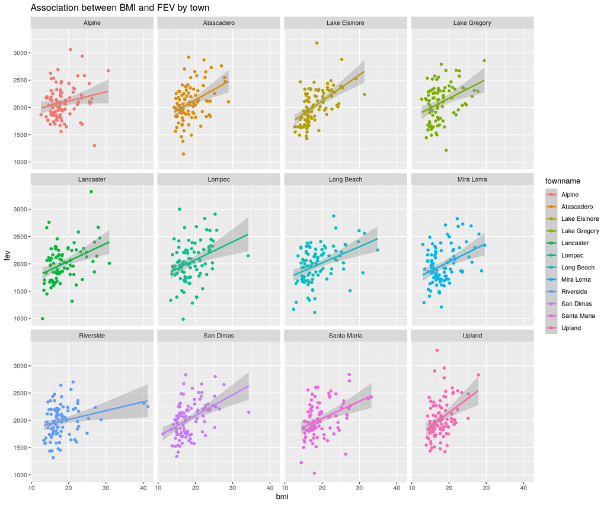

```r
merge %>%
  filter(!(townname %in% NA)) %>%
  ggplot(mapping = aes(x=bmi, y = fev, color = townname))+
  geom_point()+
  labs(title = "Association between BMI and FEV by town")+
  facet_wrap(~townname, nrow = 3)+
  geom_smooth(method = "lm")
```

## 2. Stacked Histograms of FEV by BMI Category and FEV by smoke/gas exposure

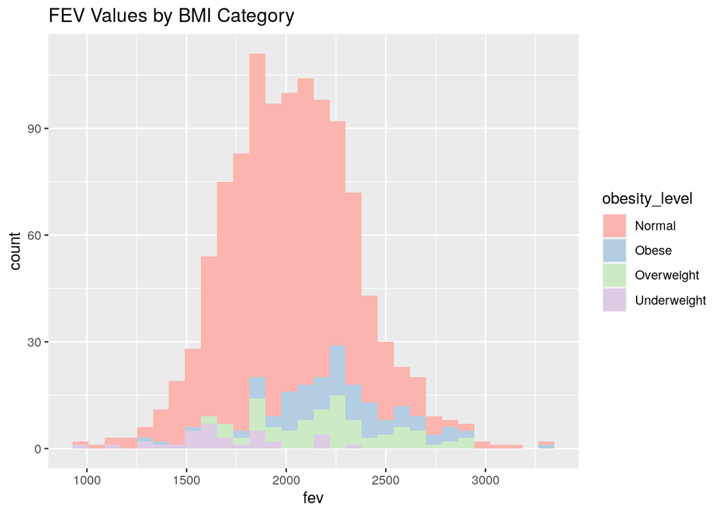

```r
merge %>%
  filter(!(townname %in% NA)) %>%
  ggplot()+
  geom_histogram(mapping = aes(x=fev,fill=obesity_level))+
  labs(title = "FEV Values by BMI Category")+
  scale_fill_brewer(palette="Pastel1")
```

Overall, those that are underweight have lower FEV values and those that are overweight and obese have higher FEV values. Those that have a normal BMI are found to have a wide range of FEV values, therefore there is another factor that is causing the differences in FEV.

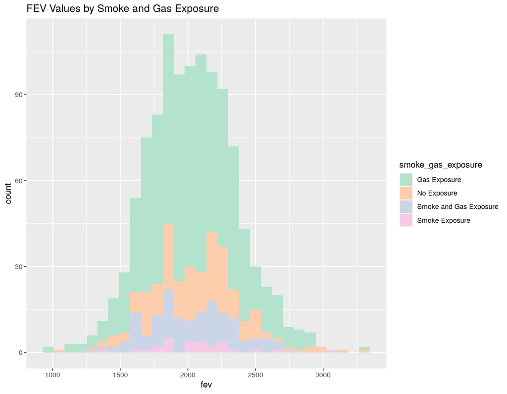

```r
merge %>%
  filter(!(townname %in% NA)) %>%
  ggplot()+
  geom_histogram(mapping = aes(x = fev,fill=smoke_gas_exposure))+
  labs(title= "FEV Values by Smoke and Gas Exposure")+
  scale_fill_brewer(palette = "Pastel2")
```

The spread of FEV values by Smoke and Gas Exposure seems to be fairly even across the four categories. Those that have only been exposed to second-hand smoke have FEV values that are centralized, but this could be due to the small sample size of this category.

## 3. Barchart of BMI by Smoke/Gas Exposure

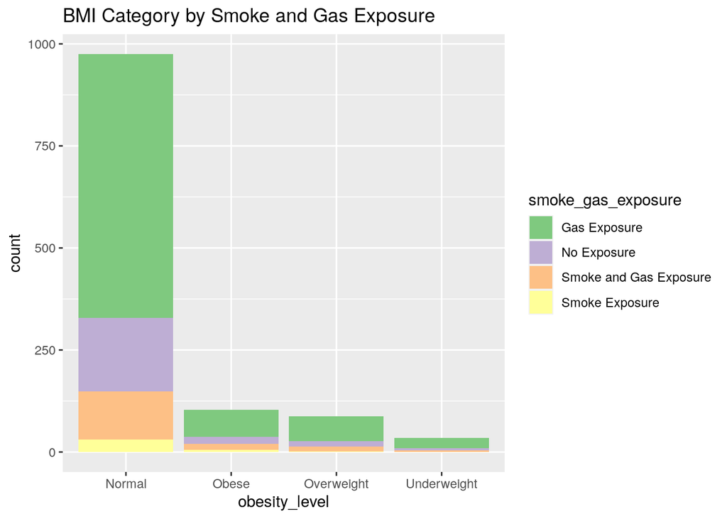

```r
merge %>%
  ggplot()+
  geom_bar(mapping = aes(x = obesity_level, fill = smoke_gas_exposure))+
  labs(title = "BMI Category by Smoke and Gas Exposure")+
  scale_fill_brewer(palette = "Accent")
```

Overall, the barchart shows that a majority of those with normal BMI have been exposed to gas exposure. This trend is true for the rest of the BMI categories as well, but this could be due to the large proportion of those that have been exposed to gas compared to the rest of the population.

## 4. Statistical Summary Graphs

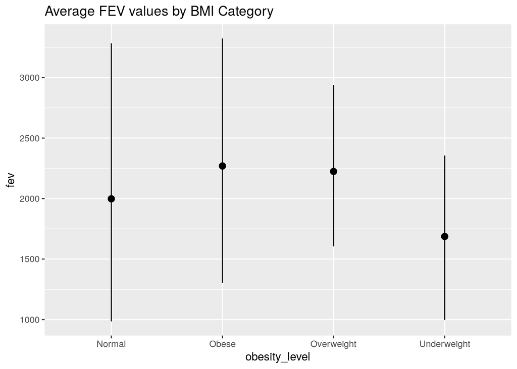

```r
merge %>%
  ggplot()+
  stat_summary(mapping = aes(x = obesity_level, y = fev),
               fun.min = min,
               fun.max = max,
               fun = mean)+
  labs(title = "Average FEV values by BMI Category")
```

The summary graphs show the mean FEV values based on obesity values, while also indicating the minimum and maximum values for each category. According to this graph, the mean FEV values are the biggest for those that are obese and overweight, while the mean FEV value is the smallest for those that are underweight. There is not much different in the mean FEV between those who are obese and overweight, but the range of FEV values for those who are overweight is smaller.

## 5. Leaflet Map for PM2.5 Concentration

```r
library(leaflet)

pm2.5col = colorNumeric(c('darkgreen','goldenrod','brown'), domain = merge$pm25_mass)
merge %>%
  leaflet() %>%
  addProviderTiles('CartoDB.Positron') %>%
  addCircles(lat = ~lat, lng = ~lon, label=~paste0(round(pm25_mass,2)), color = ~pm2.5col(pm25_mass), opacity = 1, fillOpacity = 1, radius = 500) %>%
  addLegend('bottomleft',pal = pm2.5col, values = merge$pm25_mass, title = 'PM 2.5 Concentration', opacity =1)
```

[interactive chart not shown]

According to the leaflet map, the locations with the highest PM 2.5 Concentration is located in or next to cities. The highest PM 2.5 concentrations were recorded near Riverside, Pasadena, and Long BEach. The lowest PM 2.5 concentrations were recorded in ares that are far away from big cities, such as San Luis Obispo, Lancaster, and San Diego.

## 6. Is PM 2.5 Related to FEV?

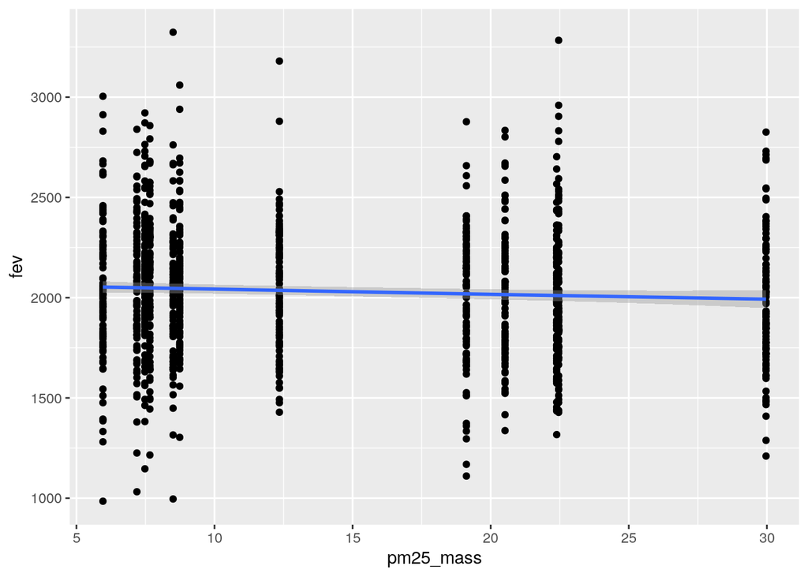

```r
merge %>%
  ggplot(mapping = aes(x = pm25_mass,y = fev))+
  geom_point()+
  geom_smooth()
```

Overall, there seems to be a slight negative relationship between PM 2.5 concentration and FEV. However, due to the scatter of data in FEV is it difficult to determine the exact relationship between the two.

Therefore, the average FEV value for each town (which was recorded to have the same PM 2.5 concentration) were calculated and the relationship between PM2.5 and FEV was examimed.

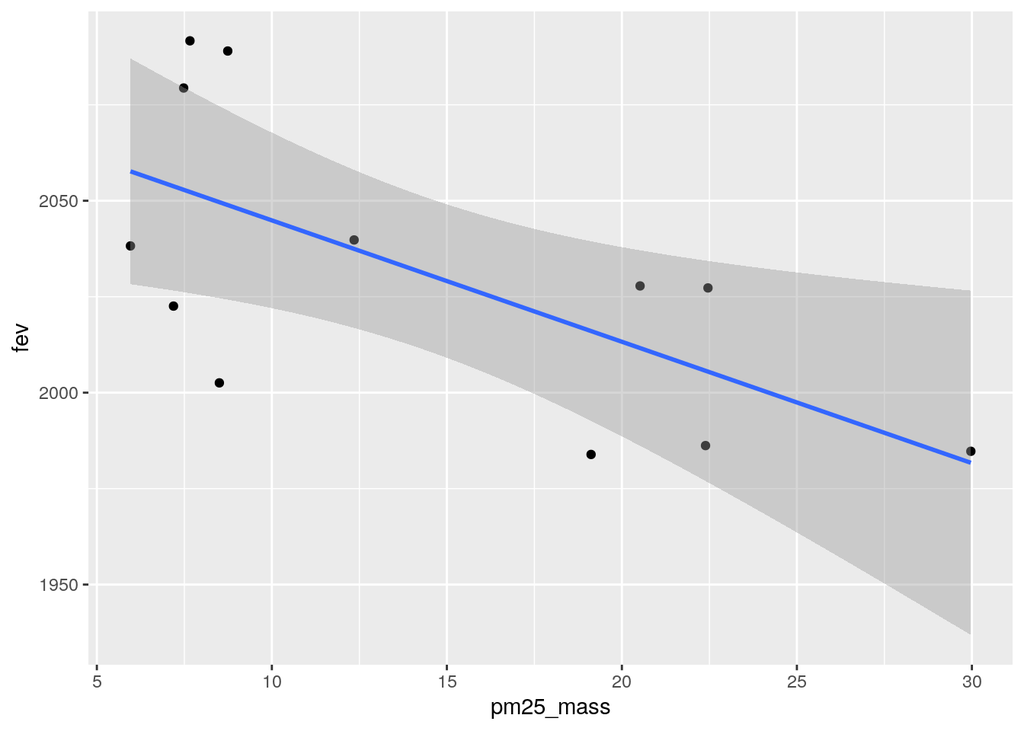

```r
data <- merge %>%
  group_by(townname,pm25_mass)%>%
  filter(!(fev %in% NA)) %>%
  summarise_at(vars(fev),
               list(mean))

data %>%
  ggplot(mapping = aes(x = pm25_mass,y=fev))+
  geom_point()+
  geom_smooth(method = "lm")
```

```r
lm(fev~pm25_mass,data=data) %>% summary()
```

```
##
## Call:
## lm(formula = fev ~ pm25_mass, data = data)
##
## Residuals:
##     Min      1Q  Median      3Q     Max
## -47.079 -22.421   2.665  22.983  40.144
##
## Coefficients:
##             Estimate Std. Error t value Pr(>|t|)
## (Intercept) 2076.511     18.856 110.124   <2e-16 ***
## pm25_mass     -3.163      1.156  -2.736    0.021 *
## ---
## Signif. codes:  0 '***' 0.001 '**' 0.01 '*' 0.05 '.' 0.1 ' ' 1
##
## Residual standard error: 30.98 on 10 degrees of freedom
## Multiple R-squared:  0.4281, Adjusted R-squared:  0.3709
## F-statistic: 7.486 on 1 and 10 DF,  p-value: 0.02097
```

Looking at the average FEV values for each PM 2.5 concentration, the negative relationship between PM 2.5 and FEV seems more clear. After doing a linear regression test, it shows that the negative correlation between PM2.5 and FEV is statistically significant.